# Prediction Assignment Writeup

GERALDO

2023-02-22

## Datos

Los datos de entrenamiento para este proyecto están disponibles aquí:

https://d396qusza40orc.cloudfront.net/predmachlearn/pml-training.csv

Los datos de prueba están disponibles aquí:

https://d396qusza40orc.cloudfront.net/predmachlearn/pml-testing.csv

```r
# Descargue los conjuntos de datos de entrenamiento y prueba
download.file("https://d396qusza40orc.cloudfront.net/predmachlearn/pml-training.csv","training.csv",method = "curl")
download.file("https://d396qusza40orc.cloudfront.net/predmachlearn/pml-testing.csv","testing.csv",method = "curl")
```

## Análisis

Primero, comenzamos exportando los datos. Uno puede simplemente descargar los conjuntos de datos de entrenamiento y prueba usado arriba.

Ahora vamos a cargar los datos en la memoria:

```r
# Cargue los conjuntos de datos de entrenamiento y prueba
training <- as_tibble(fread("training.csv",na.strings=c('#DIV/0!', '', 'NA')))
testing  <- as_tibble(fread("testing.csv",na.strings=c('#DIV/0!', '', 'NA')))
```

Ahora que tenemos los datos en la memoria, vayamos a la parte divertida. Lo primero que debemos hacer es dividir los datos de entrenamiento en dos partes. Usaremos el 70 % de estos datos para entrenar nuestro modelo y el 30 % restante para validarlo:

```r
# Ahora divida la capacitación en pruebas y validación reales
set.seed(1234) # ¡No olvide la reproducibilidad!
trainingDS <- createDataPartition( y = training$classe,
                                   p = 0.7,
                                   list = FALSE)
actual.training <- training[trainingDS,]
actual.validation <- training[-trainingDS,]
```

A continuación, debemos preparar los datos para el modelado. Si observa los datos de entrenamiento, verá que hay una serie de variables que no tienen variación o que tienen una gran fracción de valores faltantes. Estos realmente no nos ayudarán de ninguna manera significativa. Por lo tanto, vamos a limpiarlos para un modelado saludable:

```r
# Ahora limpia las variables con varianza cero
# Tenga cuidado, elimine las mismas variables en ambos casos
nzv <- nearZeroVar(actual.training)
actual.training <- actual.training[,-nzv]
actual.validation <- actual.validation[,-nzv]

# Eliminar variables que son en su mayoría NA
mostlyNA <- sapply(actual.training,function(x) mean(is.na(x))) > 0.95
actual.training <- actual.training[,mostlyNA==FALSE]
actual.validation <- actual.validation[,mostlyNA==FALSE]

# En este punto ya hemos bajado a 59 variables de 160
# Vea que las primeras 5 variables son identificadores que son
# probablemente no sea útil para la predicción, así que deshazte de esos
# Bajando el número total de variables a 54 (53 para predicción)
actual.training <- actual.training[,-(1:5)]
actual.validation <- actual.validation[,-(1:5)]
```

En este punto, tenemos datos limpios y saludables que podemos usar para construir modelos. Construiremos dos modelos: un bosque aleatorio y un modelo potenciado generalizado. Los entrenaremos en la parte de entrenamiento del conjunto de datos de entrenamiento original y luego los probaremos en la parte de validación del conjunto de datos de entrenamiento original:

```r
# Ahora construyamos un modelo de bosque aleatorio
set.seed(1234)
modelRF  <- train( classe ~.,
                   data = actual.training,
                   method = "rf",
                   trControl = trainControl(method="cv",number=3) )
# También se puede construir un modelo potenciado generalizado y comparar su precisión
# al modelo de bosque aleatorio
set.seed(1234)
modelBM <- train( classe ~.,
                  data = actual.training,
                  method = "gbm",
                  trControl = trainControl(method="repeatedcv",number = 5,repeats = 1),
                  verbose = FALSE)
```

Luego, veamos qué tan bien funcionan estos dos modelos al predecir los valores en el conjunto de datos de validación. Esto se puede lograr fácilmente prediciendo los valores en el conjunto de validación y luego comparando las predicciones con los valores reales.

```r
# Ahora obtenga la predicción en la parte de validación y vea qué tan bien lo hacemos
prediction.validation.rf <- predict(modelRF,actual.validation)
#as.factor(actual.validation$classe)
conf.matrix.rf <- confusionMatrix(prediction.validation.rf,as.factor(actual.validation$classe))
print(conf.matrix.rf)
```

```
## Confusion Matrix and Statistics
##
##           Reference
## Prediction    A    B    C    D    E
##          A 1674    3    0    0    0
##          B    0 1135    5    0    0
##          C    0    1 1021    4    0
##          D    0    0    0  959    0
##          E    0    0    0    1 1082
##
## Overall Statistics
##
##                Accuracy : 0.9976
##                  95% CI : (0.996, 0.9987)
##     No Information Rate : 0.2845
##     P-Value [Acc > NIR] : < 2.2e-16
##
##                   Kappa : 0.997
##
##  Mcnemar's Test P-Value : NA
##
## Statistics by Class:
##
##                      Class: A Class: B Class: C Class: D Class: E
## Sensitivity            1.0000   0.9965   0.9951   0.9948   1.0000
## Specificity            0.9993   0.9989   0.9990   1.0000   0.9998
## Pos Pred Value         0.9982   0.9956   0.9951   1.0000   0.9991
## Neg Pred Value         1.0000   0.9992   0.9990   0.9990   1.0000
## Prevalence             0.2845   0.1935   0.1743   0.1638   0.1839
## Detection Rate         0.2845   0.1929   0.1735   0.1630   0.1839
## Detection Prevalence   0.2850   0.1937   0.1743   0.1630   0.1840
## Balanced Accuracy      0.9996   0.9977   0.9970   0.9974   0.9999
```

```r
# Ahora obtenga la predicción en la parte de validación y vea qué tan bien lo hacemos
prediction.validation.bm <- predict(modelBM,actual.validation)
conf.matrix.bm <- confusionMatrix(prediction.validation.bm,as.factor(actual.validation$classe))
print(conf.matrix.bm)
```

```
## Confusion Matrix and Statistics
##
##           Reference
## Prediction    A    B    C    D    E
##          A 1671    8    0    2    0
##          B    2 1117    8    5    1
##          C    0   13 1018    8    1
##          D    1    1    0  948    4
##          E    0    0    0    1 1076
##
## Overall Statistics
##
##                Accuracy : 0.9907
##                  95% CI : (0.9879, 0.993)
##     No Information Rate : 0.2845
##     P-Value [Acc > NIR] : < 2.2e-16
##
##                   Kappa : 0.9882
##
##  Mcnemar's Test P-Value : NA
##
## Statistics by Class:
##
##                      Class: A Class: B Class: C Class: D Class: E
## Sensitivity            0.9982   0.9807   0.9922   0.9834   0.9945
## Specificity            0.9976   0.9966   0.9955   0.9988   0.9998
## Pos Pred Value         0.9941   0.9859   0.9788   0.9937   0.9991
## Neg Pred Value         0.9993   0.9954   0.9983   0.9968   0.9988
## Prevalence             0.2845   0.1935   0.1743   0.1638   0.1839
## Detection Rate         0.2839   0.1898   0.1730   0.1611   0.1828
## Detection Prevalence   0.2856   0.1925   0.1767   0.1621   0.1830
## Balanced Accuracy      0.9979   0.9887   0.9938   0.9911   0.9971
```

Podemos investigar un poco más nuestro modelo potenciado generalizado para ver qué variables tienen la mayor influencia relativa:

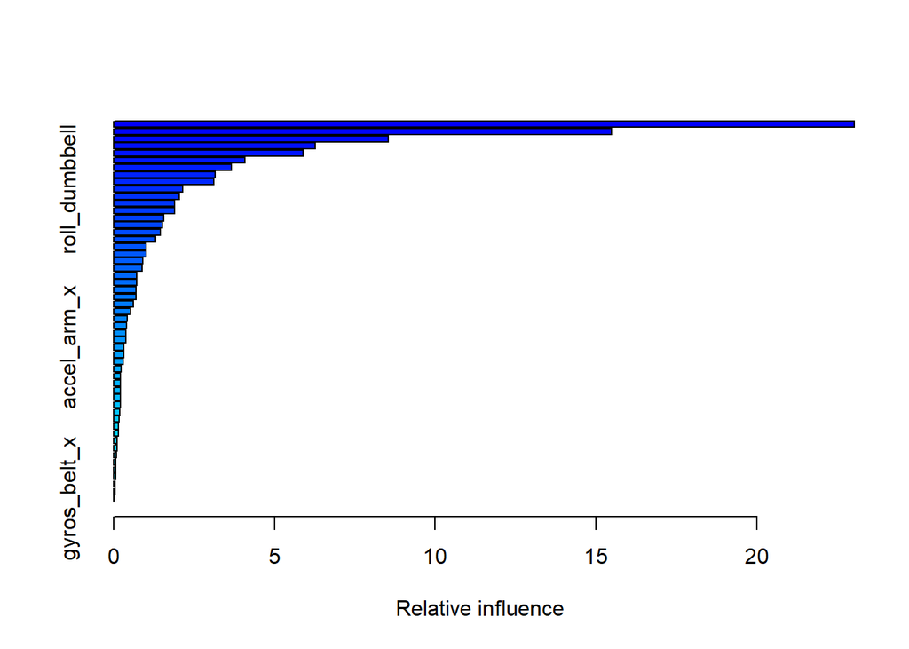

```
##                                       var     rel.inf
## num_window                     num_window 23.02471749
## roll_belt                       roll_belt 15.48259859
## pitch_forearm               pitch_forearm  8.54290940
## yaw_belt                         yaw_belt  6.27837739
## magnet_dumbbell_z       magnet_dumbbell_z  5.89290676
## magnet_dumbbell_y       magnet_dumbbell_y  4.08930789
## roll_forearm                 roll_forearm  3.65447344
## magnet_belt_z               magnet_belt_z  3.16390798
## pitch_belt                     pitch_belt  3.12099699
## roll_dumbbell               roll_dumbbell  2.15700839
## accel_forearm_x           accel_forearm_x  2.04976758
## gyros_dumbbell_y         gyros_dumbbell_y  1.90510934
## accel_dumbbell_z         accel_dumbbell_z  1.89822710
## gyros_belt_z                 gyros_belt_z  1.56784601
## magnet_forearm_z         magnet_forearm_z  1.52666407
## accel_dumbbell_y         accel_dumbbell_y  1.45721448
## accel_dumbbell_x         accel_dumbbell_x  1.30627302
## accel_forearm_z           accel_forearm_z  1.01663473
## magnet_belt_x               magnet_belt_x  1.01056115
## magnet_arm_x                 magnet_arm_x  0.91096070
## yaw_arm                           yaw_arm  0.88053350
## roll_arm                         roll_arm  0.71785293
## magnet_belt_y               magnet_belt_y  0.70902249
## magnet_dumbbell_x       magnet_dumbbell_x  0.70094881
## magnet_arm_z                 magnet_arm_z  0.69712378
## gyros_arm_y                   gyros_arm_y  0.61659042
## accel_belt_z                 accel_belt_z  0.53356713
## magnet_arm_y                 magnet_arm_y  0.41705625
## gyros_dumbbell_x         gyros_dumbbell_x  0.39885415
## gyros_belt_y                 gyros_belt_y  0.37846913
## accel_arm_y                   accel_arm_y  0.37309887
## accel_arm_x                   accel_arm_x  0.32766064
## total_accel_dumbbell total_accel_dumbbell  0.31600646
## magnet_forearm_x         magnet_forearm_x  0.29145225
## gyros_arm_x                   gyros_arm_x  0.23136039
## total_accel_forearm   total_accel_forearm  0.22085585
## magnet_forearm_y         magnet_forearm_y  0.21886431
## pitch_dumbbell             pitch_dumbbell  0.21192682
## gyros_forearm_z           gyros_forearm_z  0.20770713
## accel_forearm_y           accel_forearm_y  0.20365259
## total_accel_arm           total_accel_arm  0.19390473
## yaw_dumbbell                 yaw_dumbbell  0.16619682
## accel_arm_z                   accel_arm_z  0.15813003
## gyros_dumbbell_z         gyros_dumbbell_z  0.14897973
## yaw_forearm                   yaw_forearm  0.11681669
## gyros_forearm_y           gyros_forearm_y  0.10599657
## pitch_arm                       pitch_arm  0.08064634
## accel_belt_y                 accel_belt_y  0.07470828
## gyros_arm_z                   gyros_arm_z  0.06230493
## gyros_forearm_x           gyros_forearm_x  0.05896485
## total_accel_belt         total_accel_belt  0.05254486
## accel_belt_x                 accel_belt_x  0.04025166
## gyros_belt_x                 gyros_belt_x  0.03148813
```

```r
# Imprimir el resumen de nuestro GBM
print(summary(modelBM))
```

La lista anterior muestra la clasificación de las variables en nuestro GBM. Vemos que num_window, roll_belt y pitch_forearm son los de mayor rendimiento. Podemos ver algunas parcelas que demuestran su poder:

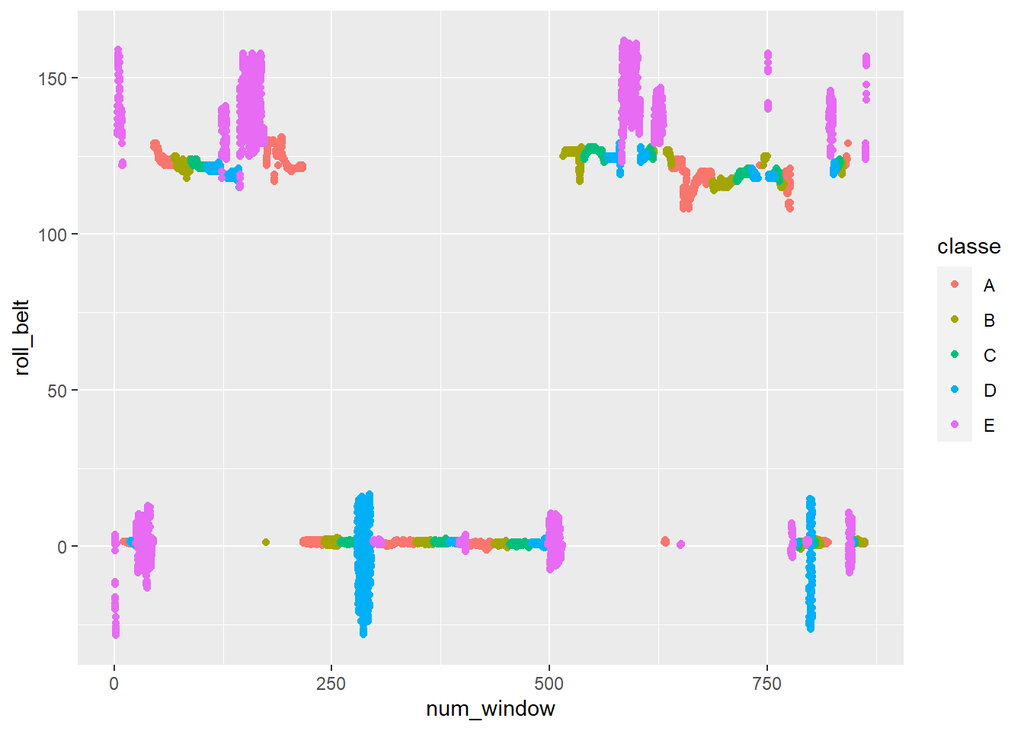

```r
qplot(num_window, roll_belt    , data = actual.training, col = classe)
```

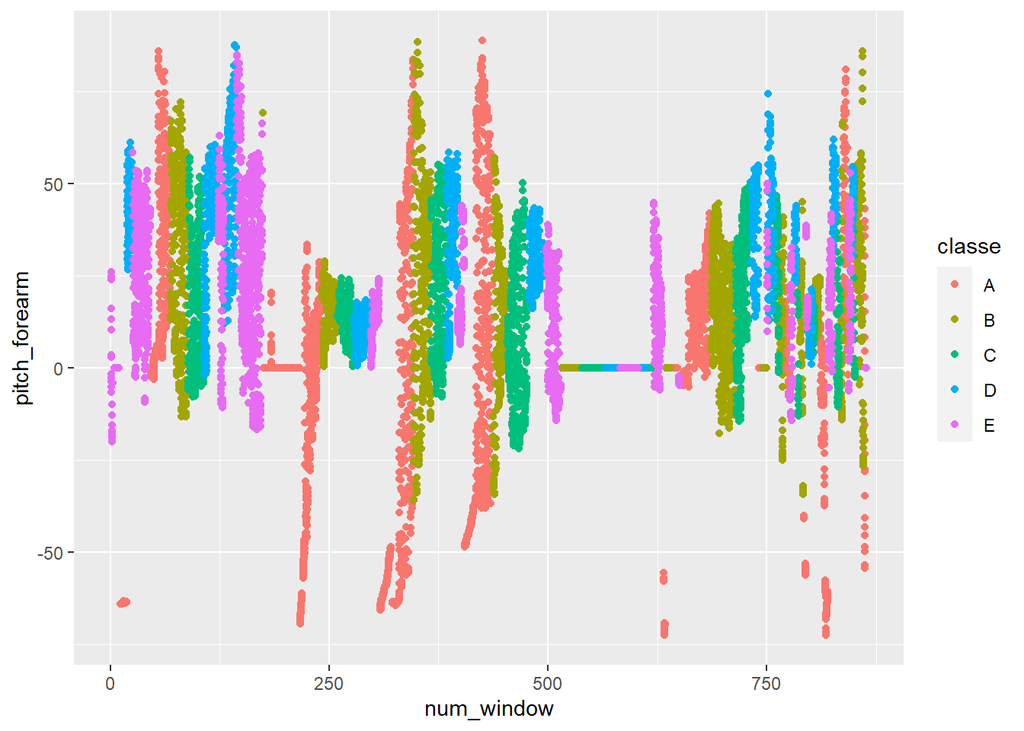

```r
qplot(num_window, pitch_forearm, data = actual.training, col = classe)
```

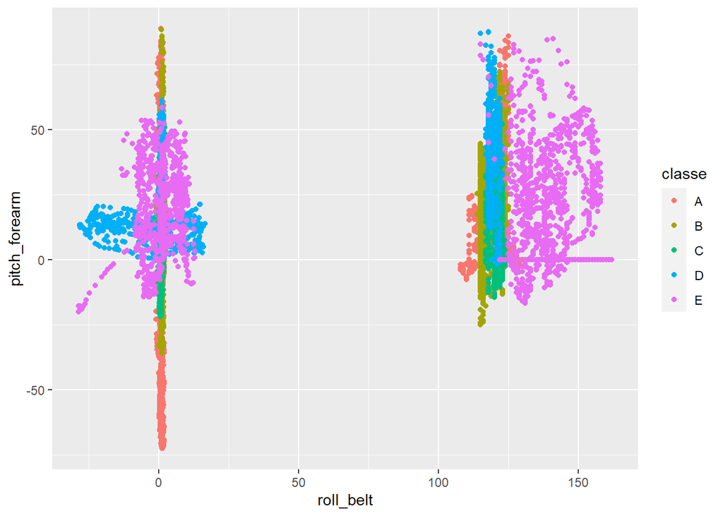

```r
qplot(roll_belt , pitch_forearm, data = actual.training, col = classe)
```

```r
# Ahora obtenga la predicción en la parte de prueba y vea lo que obtenemos
prediction.testing.rf <- predict(modelRF,testing)
print(prediction.testing.rf)
```

```
##  [1] B A B A A E D B A A B C B A E E A B B B
## Levels: A B C D E
```